# #TidyTuesday 2 / 10.9.2019: Week 37 Amusement Park Injuries

novica

10/9/2019

## *Post hoc* synopsis

Ова веројатно е еден од покорисните документи за нови TidyTuesdayAtKIKA посетители. Вклучен е код за инспекција и чистење на проблематични варијабли, како текстуални така и нумерички (датуми). Има неколку типови на визуализации на податоците, со основен `ggplot2` код и специјализирани пакети. И има кратко теоретско објаснување за синтаксата на `ggplot2` како и неколку корисни кратенки за `RStudio`.

## Intro

> (1/n) Michael Pollan’s advice if he taught [#Rstats](https://twitter.com/hashtag/Rstats?src=hash&ref_src=twsrc%5Etfw)/[#Python](https://twitter.com/hashtag/Python?src=hash&ref_src=twsrc%5Etfw) programming for [@datacarpentry](https://twitter.com/datacarpentry?ref_src=twsrc%5Etfw):  
> 1. Write code  
> 2. Not too much  
> 3. Mostly plots

> — Dr. Michael Koontz (@_mikoontz) [July 26, 2016](https://twitter.com/_mikoontz/status/758021742078025728?ref_src=twsrc%5Etfw)

## Recap

- .Rmd (R Markdown) е околината во која ќе работиме бидејќи овозможува код, текст, коментари и аутпут да се презентираат заедно;
- Нов R Notebook: Мени: `File -> New File -> R notebook`
- Корисни кратенки:
  - insert code chunk (`ctrl+alt+i`), execute all above/below cursor (`ctr+alt+b`/`ctrl+alt+e`),
  - pipes (`ctrl+shift+m`) [not a true `bash` pipe. More a function to chain other functions]
  - `view()`

## The tidyverse

The tidyverse is an “opinionated collection of R packages designed for data science. All packages share an underlying design philosophy, grammar, and data structures.” (source: https://thomasmock.netlify.com/post/tidytuesday-a-weekly-social-data-project-in-r/)

## TidyTuesday 37 недела, 2 пат КИКА

- Податоци на [github](https://github.com/rfordatascience/tidytuesday/tree/master/data/2019/2019-09-10)
- Добар пример за реални, ‘валкани’ податоци што треба да се исчистат. Ако на пример работите во осигурителна куќа и ви речат ајде да видиме што да се прави за полиси за осигурување за повреди во забавни паркови.

## Libraties (packages) and data

Load the libraries

```r
suppressPackageStartupMessages(library(tidyverse))
```

Load the data from github

```r
tx_injuries <- readr::read_csv("https://raw.githubusercontent.com/rfordatascience/tidytuesday/master/data/2019/2019-09-10/tx_injuries.csv")

safer_parks <- readr::read_csv("https://raw.githubusercontent.com/rfordatascience/tidytuesday/master/data/2019/2019-09-10/saferparks.csv")
```

## Средување NA вредности

A lot of free text this week, some inconsistent `NA`s (`n/a`, `N/A`) and dates (`ymd`, `dmy`). A good chance to do some data cleaning and then take a look at frequency, type of injury, and analyze free text.

Прашање: Колку сѐ можни форми на `NA` (not applicable) има во податоците?

```r
glimpse(tx_injuries)
```

```
## Rows: 542
## Columns: 13
## $ injury_report_rec <dbl> 2032, 1897, 837, 99, 55, 780, 253, 253, 55, 55, 2032~
## $ name_of_operation <chr> "Skygroup Investments LLC DBA iFly Austin", "Willie ~
## $ city              <chr> "Austin", "Galveston", "Grapevine", "San Antonio", "~
## $ st                <chr> "TX", "TX", "TX", "TX", "AZ", "TX", "TX", "TX", "AZ"~
## $ injury_date       <chr> "2/12/2013", "3/2/2013", "3/3/2013", "3/3/2013", "3/~
## $ ride_name         <chr> "I Fly", "Gulf Glider", "Howlin Tornado", "Scooby Do~
## $ serial_no         <chr> "SV024", "GS-11-10-WG-14", "0643-C1-T1-TN60", "n/a",~
## $ gender            <chr> "F", "F", "F", "F", "F", "F", "F", "M", "M", "F", "M~
## $ age               <chr> "37", "43", "n/a", "51", "17", "40", "36", "23", "40~
## $ body_part         <chr> "Mouth", "Knee", "Right Shoulder", "Lower Leg", "Hea~
## $ alleged_injury    <chr> "Student hit mouth on wall", "Alleged arthroscopy to~
## $ cause_of_injury   <chr> "Student attempted unfamiliar manuever", "Hit her kn~
## $ other             <chr> NA, "Prior history of problems with this knee. First~
```

```r
#map(tx_injuries, unique)
```

Колку што можевме да видиме од `dplyr::glimpse()` командата, има:`N/A`, `n/a`. Можеме да ги конвертираме овие форми на `NA` во стандардна `R` `NA` со функцијата `dplyr::na_if()` (за потсетување, синтаксата со `::` означува `пакет::функција`).

```r
tx_injuries <- tx_injuries %>%
    mutate(age = na_if(age, "n/a")) %>%
    mutate(age = na_if(age, "N/A")) %>%
    mutate(age = na_if(age, "0")) %>%
    mutate(age = as.numeric(age)) %>%
    mutate(gender = na_if(gender, "n/a")) %>%
    mutate(gender = na_if(gender, "N/A")) %>%
    mutate(gender=str_to_upper(gender)) %>%
    mutate(gender = as_factor(gender)) %>%
    mutate(injury_date = na_if(injury_date, "n/a")) %>%
    mutate(injury_date = na_if(injury_date, "#########"))

#map(tx_injuries, unique)
```

## Компјутеризирано барање на `NA`

Очигледно е дека горниот приод каде повикуваме `na_if` за секоја варијабла и можна форма на `NA` не е многу ефикасен. Особено ако имаме посериозен проблем со повеќе колони со податоци кои сакаме да ги процесираме. Во пракса ваквото чистење на податоци најдобро се прави со custom функции, особено кога иста или слична трансформација треба да се аплицира на повеќе вектори (колони).

```r
# make a function to mutate a column to fix NAs
fix_na <- function(vect, na_strings) {
  vect[vect %in% na_strings] <- NA
  return(vect)
}

# find possible NA values
possible_na <-
  tx_injuries %>%
  gather(col_name, value) %>%
  filter(str_detect(value, "^n|^N"), str_length(value) < 5) %>%
  distinct(value, .keep_all = FALSE) %>%
  filter(!value %in% c("Neck", "Nose", "neck")) %>%
  pull(value)

possible_na
```

```
## [1] "N/A" "n/a"
```

```r
# apply our custom function to all columns
# while using all possible NA we just found
tx_injuries_na_fixed <- tx_injuries %>%
  mutate_all(.funs = fix_na, na_strings = possible_na)
```

## Чистење на датуми

Со пакетот `lubridate`

```r
suppressPackageStartupMessages(library(lubridate))

tx_injuries$injury_date
```

```
##   [1] "2/12/2013" "3/2/2013"  "3/3/2013"  "3/3/2013"  "3/11/2013" "3/12/2013"
##   [7] "3/15/2013" "3/15/2013" "3/16/2013" "3/16/2013" "3/28/2013" "3/30/2013"
##  [13] "4/6/2013"  "4/11/2013" "4/12/2013" "4/14/2013" "4/20/2013" "4/27/2013"
##  [19] "4/27/2013" "4/28/2013" "4/28/2013" "4/28/2013" "5/11/2013" "41406"
##  [25] "5/12/2013" "5/18/2013" "5/18/2013" "5/26/2013" "5/27/2013" "5/29/2013"
##  [31] "5/31/2013" "41426"     "6/2/2013"  "6/4/2013"  "6/5/2013"  "6/6/2013"
##  [37] "6/7/2013"  "6/8/2013"  "41434"     "6/9/2013"  "6/13/2013" "41440"
##  [43] "6/18/2013" "6/20/2013" "6/22/2013" "6/24/2013" "6/25/2013" "6/25/2013"
##  [49] "6/26/2013" "6/27/2013" "41452"     "41452"     "41452"     "6/30/2013"
##  [55] "41455"     "6/30/2013" "7/1/2013"  "7/2/2013"  "41458"     "41458"
##  [61] "7/4/2013"  "7/5/2013"  "7/7/2013"  "7/7/2013"  "7/7/2013"  "7/7/2013"
##  [67] "7/9/2013"  "7/10/2013" "7/11/2013" "7/13/2013" "7/14/2013" "7/14/2013"
##  [73] "7/14/2013" "7/16/2013" "7/18/2013" "7/18/2013" "7/19/2013" "7/19/2013"
##  [79] "7/20/2013" "7/20/2013" "7/21/2013" "7/22/2013" "7/23/2013" "7/27/2013"
##  [85] "7/27/2013" "7/27/2013" "7/27/2013" "7/27/2013" "7/28/2013" "7/28/2013"
```

[output cut: 76 more lines]

```r
tx_injuries <- tx_injuries %>%
    mutate(injury_date = case_when(
      str_length(injury_date) == 5 ~ as_date(
        as.numeric(injury_date), origin='1899-12-30'),
      str_detect(injury_date, "/") == TRUE ~ mdy(injury_date),
      TRUE ~ as.Date(NA)
      ))


tx_injuries$injury_date
```

```
##   [1] "2013-02-12" "2013-03-02" "2013-03-03" "2013-03-03" "2013-03-11"
##   [6] "2013-03-12" "2013-03-15" "2013-03-15" "2013-03-16" "2013-03-16"
##  [11] "2013-03-28" "2013-03-30" "2013-04-06" "2013-04-11" "2013-04-12"
##  [16] "2013-04-14" "2013-04-20" "2013-04-27" "2013-04-27" "2013-04-28"
##  [21] "2013-04-28" "2013-04-28" "2013-05-11" "2013-05-12" "2013-05-12"
##  [26] "2013-05-18" "2013-05-18" "2013-05-26" "2013-05-27" "2013-05-29"
##  [31] "2013-05-31" "2013-06-01" "2013-06-02" "2013-06-04" "2013-06-05"
##  [36] "2013-06-06" "2013-06-07" "2013-06-08" "2013-06-09" "2013-06-09"
##  [41] "2013-06-13" "2013-06-15" "2013-06-18" "2013-06-20" "2013-06-22"
##  [46] "2013-06-24" "2013-06-25" "2013-06-25" "2013-06-26" "2013-06-27"
##  [51] "2013-06-27" "2013-06-27" "2013-06-27" "2013-06-30" "2013-06-30"
##  [56] "2013-06-30" "2013-07-01" "2013-07-02" "2013-07-03" "2013-07-03"
##  [61] "2013-07-04" "2013-07-05" "2013-07-07" "2013-07-07" "2013-07-07"
##  [66] "2013-07-07" "2013-07-09" "2013-07-10" "2013-07-11" "2013-07-13"
##  [71] "2013-07-14" "2013-07-14" "2013-07-14" "2013-07-16" "2013-07-18"
```

[output cut: 94 more lines]

## Графици 101

Ако се присетите на чистењето на податоците, некако излегува дека решивме да работиме со три променливи кои се различни по тип: `age`, `gender`, `injury_date`.

```r
glimpse(tx_injuries)
```

```
## Rows: 542
## Columns: 13
## $ injury_report_rec <dbl> 2032, 1897, 837, 99, 55, 780, 253, 253, 55, 55, 2032~
## $ name_of_operation <chr> "Skygroup Investments LLC DBA iFly Austin", "Willie ~
## $ city              <chr> "Austin", "Galveston", "Grapevine", "San Antonio", "~
## $ st                <chr> "TX", "TX", "TX", "TX", "AZ", "TX", "TX", "TX", "AZ"~
## $ injury_date       <date> 2013-02-12, 2013-03-02, 2013-03-03, 2013-03-03, 201~
## $ ride_name         <chr> "I Fly", "Gulf Glider", "Howlin Tornado", "Scooby Do~
## $ serial_no         <chr> "SV024", "GS-11-10-WG-14", "0643-C1-T1-TN60", "n/a",~
## $ gender            <fct> F, F, F, F, F, F, F, M, M, F, M, F, NA, M, M, F, F, ~
## $ age               <dbl> 37, 43, NA, 51, 17, 40, 36, 23, 40, 48, 10, NA, 45, ~
## $ body_part         <chr> "Mouth", "Knee", "Right Shoulder", "Lower Leg", "Hea~
## $ alleged_injury    <chr> "Student hit mouth on wall", "Alleged arthroscopy to~
## $ cause_of_injury   <chr> "Student attempted unfamiliar manuever", "Hit her kn~
## $ other             <chr> NA, "Prior history of problems with this knee. First~
```

Template за графици

```r
ggplot(data = <DATA>) +
  <GEOM_FUNCTION>(mapping = aes(<MAPPINGS>))
```

Извор: https://r4ds.had.co.nz/data-visualisation.html#first-steps

MAPPING: A `variable` is *mapped* onto a `geom`.

Examples: `age` is mapped to `x`, `gender` is mapped to `fill`

Many `geoms`. They have a corresponding `stat` function that transforms the data to make it suitable for the `geom` (?stat_boxplot)

## Histogram

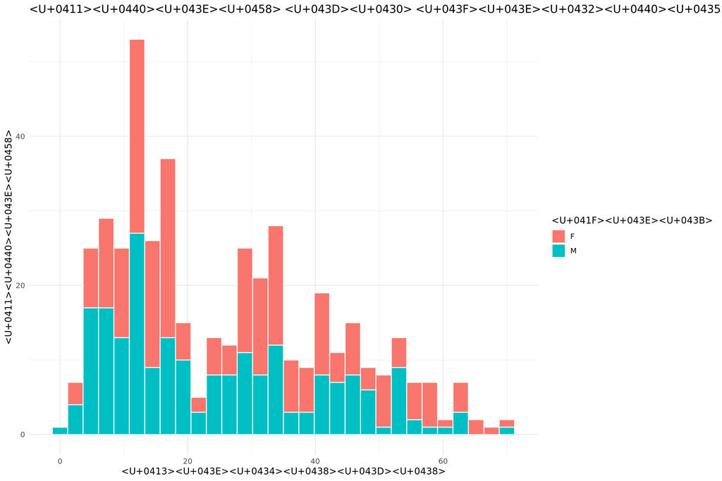

```r
ggplot(data = drop_na(tx_injuries, gender)) +
  geom_histogram(mapping = aes(x = age, fill = gender),
                 na.rm = TRUE, color="white") +
  labs(x="Години", y="Број") +
  labs(title="Број на повреди по години по пол", fill = "Пол") +
  theme_minimal()
```

## Scatterplot

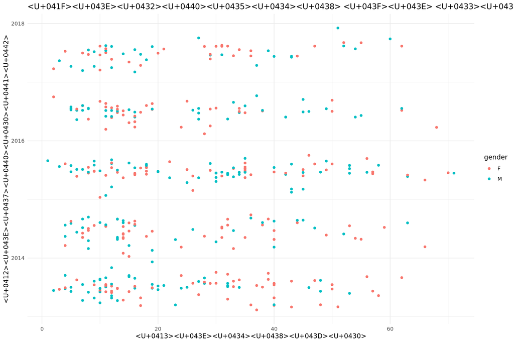

```r
ggplot(data = drop_na(tx_injuries, gender)) +
  geom_point(mapping = aes(x = age, y = injury_date, color=gender)) +
  labs(x="Година", y="Возраст") +
  labs(title="Повреди по години по возраст") +
  #facet_wrap("gender", ncol=2)
  theme_minimal()
```

## Heatmap

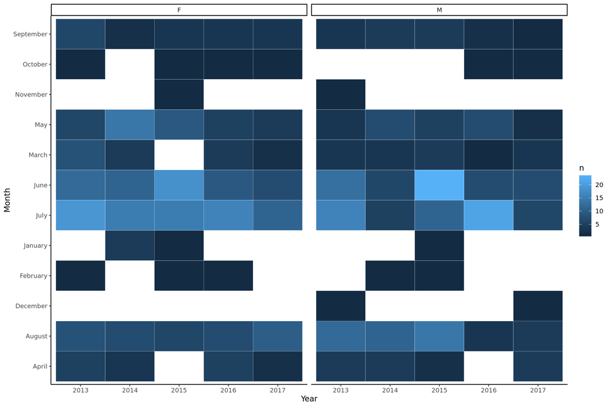

```r
tx_injuries %>% select(age, gender, injury_date) %>%
  mutate(Month=month.name[month(injury_date)]) %>%
  mutate(Year=factor(year(injury_date))) %>%
  drop_na(Month, Year, gender) %>%
  group_by(Year, Month, gender) %>%
  tally() %>%
  ggplot(data=.) +
    geom_tile(aes(y=Month, x=Year, fill=n), color="white") +
    facet_wrap("gender", ncol=2) +
      theme_classic()
```

## Ridges

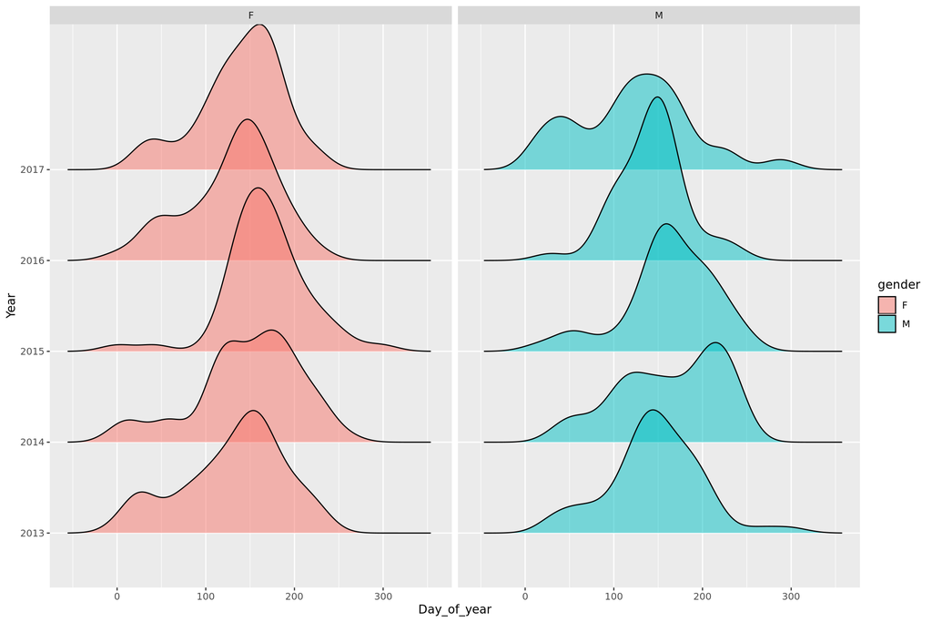

```r
suppressPackageStartupMessages(library(ggridges))

tx_injuries %>% select(age, gender, injury_date) %>%
  mutate(Month=month.name[month(injury_date)]) %>%
  mutate(Year=factor(year(injury_date))) %>%
  group_by(Year) %>%
  mutate(Day_of_year=injury_date-min(injury_date)) %>%
  drop_na(Year, Day_of_year, gender) %>%
  ggplot(data=.) +
    geom_density_ridges(mapping = aes(
      x=Day_of_year, y=Year, fill=gender), alpha=.5) +
    facet_wrap("gender", ncol=2)
```

Homework: What was potentially wrong with the assumptions for the previous graph?

## R референци

- R4DS slack канал наменет за почетници што вежбаа со #TidyTuesday
- R for Data science (https://r4ds.had.co.nz/)
- Advanced R (http://adv-r.had.co.nz/)
- TidyTuesday podcast (https://podtail.com/podcast/tidy-tuesday/)